# **Regression Project: Boston House Price Prediction**

# **Marks: 60**

Welcome to the project on regression. We will use the **Boston house price dataset** for this project.

## **Objective**

The problem at hand is to **predict the housing prices of a town or a suburb based on the features of the locality provided to us**. In the process, we need to **identify the most important features affecting the price of the house**. We need to employ techniques of data preprocessing and build a linear regression model that predicts the prices for the unseen data.

## **Dataset**

Each record in the database describes a house in Boston suburb or town. The data was drawn from the Boston Standard Metropolitan Statistical Area (SMSA) in 1970. Detailed attribute information can be found below:

Attribute Information:

- **CRIM:** Per capita crime rate by town
- **ZN:** Proportion of residential land zoned for lots over 25,000 sq.ft.
- **INDUS:** Proportion of non-retail business acres per town
- **CHAS:** Charles River dummy variable (= 1 if tract bounds river; 0 otherwise)
- **NOX:** Nitric Oxide concentration (parts per 10 million)
- **RM:** The average number of rooms per dwelling
- **AGE:** Proportion of owner-occupied units built before 1940
- **DIS:** Weighted distances to five Boston employment centers
- **RAD:** Index of accessibility to radial highways
- **TAX:** Full-value property-tax rate per 10,000 dollars
- **PTRATIO:** Pupil-teacher ratio by town
- **LSTAT:** % lower status of the population
- **MEDV:** Median value of owner-occupied homes in 1000 dollars

## **Importing the necessary libraries**

```python
import pandas as pd
import numpy as np
import matplotlib.pyplot as plt
import seaborn as sns
from sklearn.model_selection import train_test_split, cross_val_score, GridSearchCV
from sklearn.linear_model import LinearRegression, Ridge, Lasso
from sklearn.metrics import mean_squared_error, mean_absolute_error, r2_score, mean_absolute_percentage_error
from sklearn.preprocessing import StandardScaler, PolynomialFeatures
from sklearn.tree import DecisionTreeRegressor
from sklearn.ensemble import RandomForestRegressor, GradientBoostingRegressor
from xgboost import XGBRegressor
from statsmodels.stats.outliers_influence import variance_inflation_factor
import statsmodels.api as sm
```

### Loading the dataset

```python
data_path = '/content/Boston.csv'
boston = pd.read_csv(data_path)
boston.head()
```

|  | CRIM | ZN | INDUS | CHAS | NOX | RM | AGE | DIS | RAD | TAX | PTRATIO | LSTAT | MEDV |
| --- | --- | --- | --- | --- | --- | --- | --- | --- | --- | --- | --- | --- | --- |
| 0 | 0.00632 | 18.0 | 2.31 | 0 | 0.538 | 6.575 | 65.2 | 4.0900 | 1 | 296 | 15.3 | 4.98 | 24.0 |
| 1 | 0.02731 | 0.0 | 7.07 | 0 | 0.469 | 6.421 | 78.9 | 4.9671 | 2 | 242 | 17.8 | 9.14 | 21.6 |
| 2 | 0.02729 | 0.0 | 7.07 | 0 | 0.469 | 7.185 | 61.1 | 4.9671 | 2 | 242 | 17.8 | 4.03 | 34.7 |
| 3 | 0.03237 | 0.0 | 2.18 | 0 | 0.458 | 6.998 | 45.8 | 6.0622 | 3 | 222 | 18.7 | 2.94 | 33.4 |
| 4 | 0.06905 | 0.0 | 2.18 | 0 | 0.458 | 7.147 | 54.2 | 6.0622 | 3 | 222 | 18.7 | 5.33 | 36.2 |

## Data Overview

- Observations
- Sanity checks

```python
boston.info()
```

```
<class 'pandas.core.frame.DataFrame'>
RangeIndex: 506 entries, 0 to 505
Data columns (total 13 columns):
 #   Column   Non-Null Count  Dtype
---  ------   --------------  -----
 0   CRIM     506 non-null    float64
 1   ZN       506 non-null    float64
 2   INDUS    506 non-null    float64
 3   CHAS     506 non-null    int64
 4   NOX      506 non-null    float64
 5   RM       506 non-null    float64
 6   AGE      506 non-null    float64
 7   DIS      506 non-null    float64
 8   RAD      506 non-null    int64
 9   TAX      506 non-null    int64
 10  PTRATIO  506 non-null    float64
 11  LSTAT    506 non-null    float64
 12  MEDV     506 non-null    float64
dtypes: float64(10), int64(3)
memory usage: 51.5 KB
```

```python
boston['AGE'] = boston['AGE'].astype(int)
boston["RM"]=boston["RM"].astype(int)
boston.head()
```

|  | CRIM | ZN | INDUS | CHAS | NOX | RM | AGE | DIS | RAD | TAX | PTRATIO | LSTAT | MEDV |
| --- | --- | --- | --- | --- | --- | --- | --- | --- | --- | --- | --- | --- | --- |
| 0 | 0.00632 | 18.0 | 2.31 | 0 | 0.538 | 6 | 65 | 4.0900 | 1 | 296 | 15.3 | 4.98 | 24.0 |
| 1 | 0.02731 | 0.0 | 7.07 | 0 | 0.469 | 6 | 78 | 4.9671 | 2 | 242 | 17.8 | 9.14 | 21.6 |
| 2 | 0.02729 | 0.0 | 7.07 | 0 | 0.469 | 7 | 61 | 4.9671 | 2 | 242 | 17.8 | 4.03 | 34.7 |
| 3 | 0.03237 | 0.0 | 2.18 | 0 | 0.458 | 6 | 45 | 6.0622 | 3 | 222 | 18.7 | 2.94 | 33.4 |
| 4 | 0.06905 | 0.0 | 2.18 | 0 | 0.458 | 7 | 54 | 6.0622 | 3 | 222 | 18.7 | 5.33 | 36.2 |

```python
boston.describe().T
```

|  | count | mean | std | min | 25% | 50% | 75% | max |
| --- | --- | --- | --- | --- | --- | --- | --- | --- |
| CRIM | 506.0 | 3.613524 | 8.601545 | 0.00632 | 0.082045 | 0.25651 | 3.677083 | 88.9762 |
| ZN | 506.0 | 11.363636 | 23.322453 | 0.00000 | 0.000000 | 0.00000 | 12.500000 | 100.0000 |
| INDUS | 506.0 | 11.136779 | 6.860353 | 0.46000 | 5.190000 | 9.69000 | 18.100000 | 27.7400 |
| CHAS | 506.0 | 0.069170 | 0.253994 | 0.00000 | 0.000000 | 0.00000 | 0.000000 | 1.0000 |
| NOX | 506.0 | 0.554695 | 0.115878 | 0.38500 | 0.449000 | 0.53800 | 0.624000 | 0.8710 |
| RM | 506.0 | 5.776680 | 0.778123 | 3.00000 | 5.000000 | 6.00000 | 6.000000 | 8.0000 |
| AGE | 506.0 | 68.156126 | 28.203316 | 2.00000 | 45.000000 | 77.00000 | 94.000000 | 100.0000 |
| DIS | 506.0 | 3.795043 | 2.105710 | 1.12960 | 2.100175 | 3.20745 | 5.188425 | 12.1265 |
| RAD | 506.0 | 9.549407 | 8.707259 | 1.00000 | 4.000000 | 5.00000 | 24.000000 | 24.0000 |
| TAX | 506.0 | 408.237154 | 168.537116 | 187.00000 | 279.000000 | 330.00000 | 666.000000 | 711.0000 |
| PTRATIO | 506.0 | 18.455534 | 2.164946 | 12.60000 | 17.400000 | 19.05000 | 20.200000 | 22.0000 |
| LSTAT | 506.0 | 12.653063 | 7.141062 | 1.73000 | 6.950000 | 11.36000 | 16.955000 | 37.9700 |
| MEDV | 506.0 | 22.532806 | 9.197104 | 5.00000 | 17.025000 | 21.20000 | 25.000000 | 50.0000 |

## Exploratory Data Analysis (EDA)

- EDA is an important part of any project involving data.
- It is important to investigate and understand the data better before building a model with it.
- A few questions have been mentioned below which will help you approach the analysis in the right manner and generate insights from the data.
- A thorough analysis of the data, in addition to the questions mentioned below, should be done.

**Questions:**

1. What does the distribution of 'MEDV' look like?
2. What can we infer form the correlation heatmap? Is there correlation between the dependent and independent variables?
3. What are all the inferences that can be found by doing univariate analysis for different variables?
4. Do bivariate analysis to visualize the relationship between the features having significant correlations (>= 0.7 or <= -0.7)

### What does the distribution of 'MEDV' look like?

The distribution of 'MEDV' (Median value of owner-occupied homes in $1000) is skewed. Most of the houses have a median value in the range of $15,000 to $30,000, with a peak around $20,000. There are some high-valued houses around $50,000

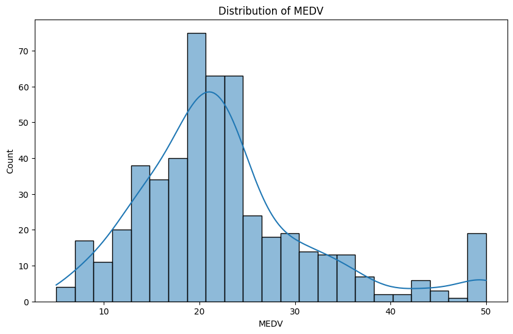

```python
plt.figure(figsize=(10, 6))
sns.histplot(boston['MEDV'], kde=True)
plt.title('Distribution of MEDV')
plt.show()
```

### What can we infer from the correlation heatmap? Is there correlation between the dependent and independent variables?

From the correlation heatmap, we can infer the following:

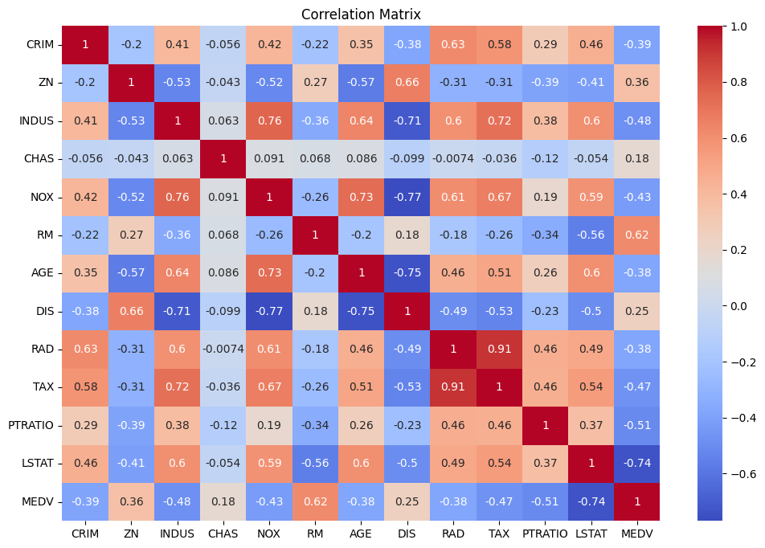

```python
plt.figure(figsize=(12, 8))
sns.heatmap(boston.corr(), annot=True, cmap='coolwarm')
plt.title('Correlation Matrix')
plt.show()
```

### What are all the inferences that can be found by doing univariate analysis for different variables?

CRIM: The distribution is highly right-skewed, indicating most areas have a low per capita crime rate, but a few areas have a very high crime rate.

**ZN:** Most of the data points are at 0, indicating many areas do not have large residential lots, but a few areas have a significant proportion of large residential lots.

**INDUS:** The distribution is bimodal, with peaks around 7.5 and 18, indicating areas with varying proportions of non-retail business acres.

**CHAS:** Most areas do not bound the Charles River (value 0).

**NOX:** The distribution is slightly right-skewed, with most areas having moderate NOX concentration levels.

**RM:** The distribution is approximately normal, centered around 6 rooms per dwelling.

**TAX:** The distribution is bimodal, indicating varying property tax rates in different areas.

**PTRATIO:** The distribution has a peak around 20, indicating most areas have a pupil-teacher ratio around this value.

**LSTAT:** The distribution is right-skewed, indicating most areas have a moderate to low percentage of lower-status population.

**MEDV:** The distribution is right-skewed, with most houses having a median value in the range of $15,000 to $30,000.

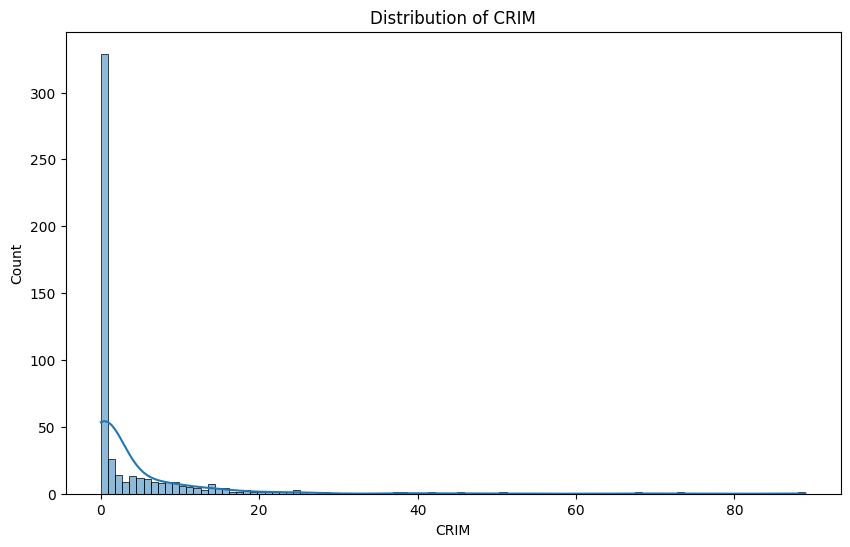

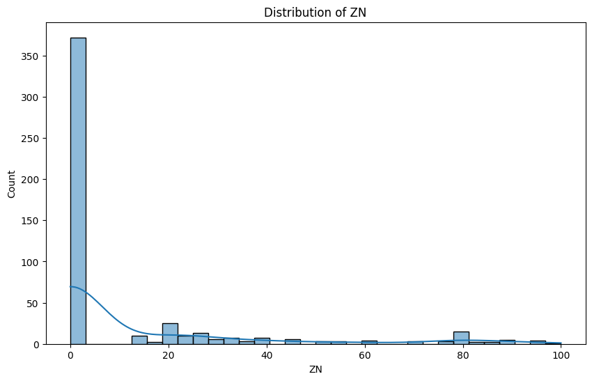

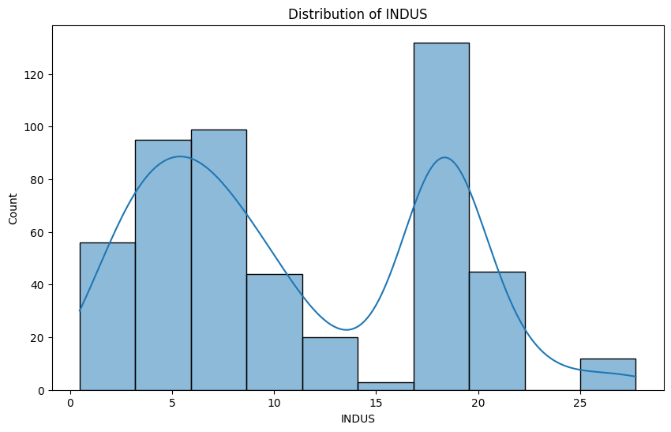

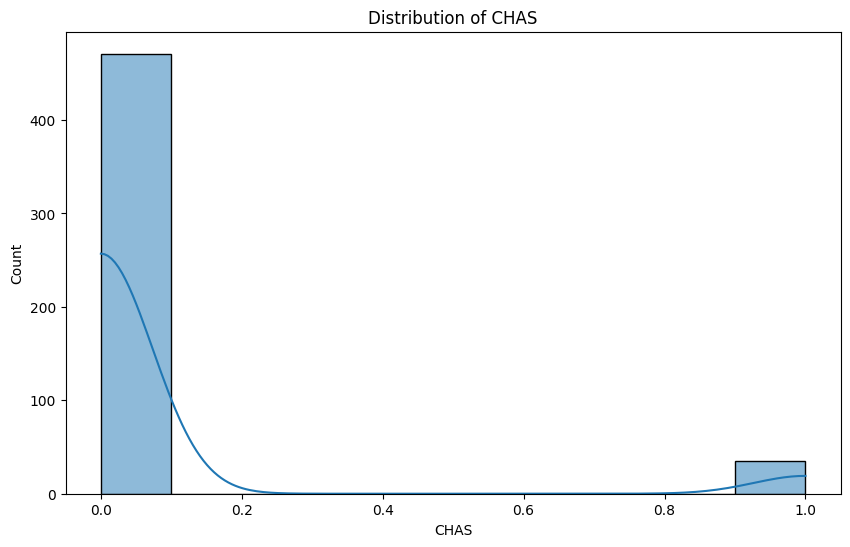

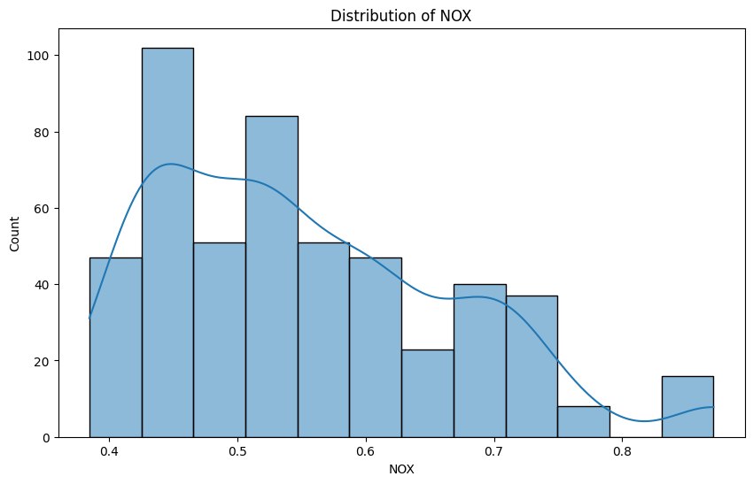

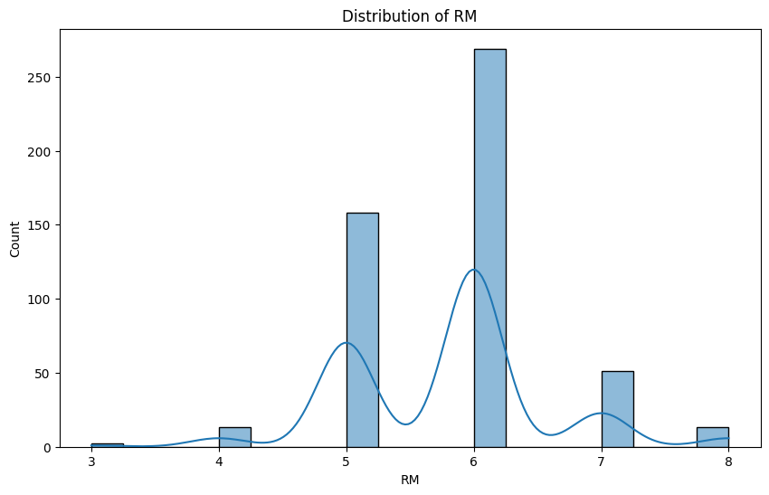

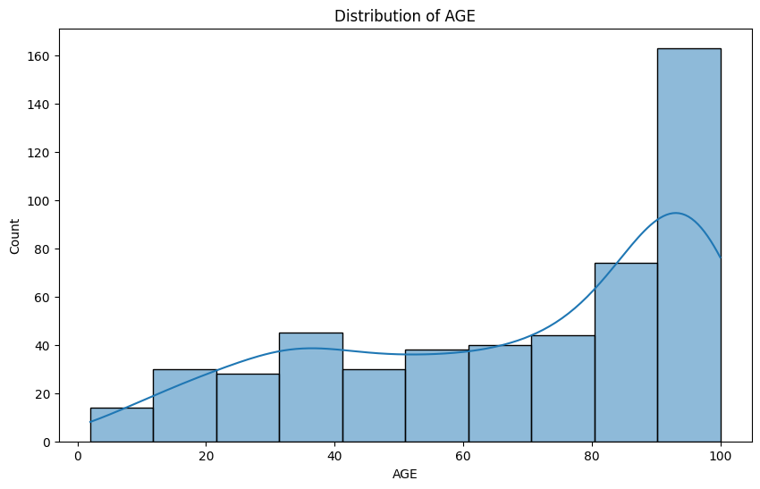

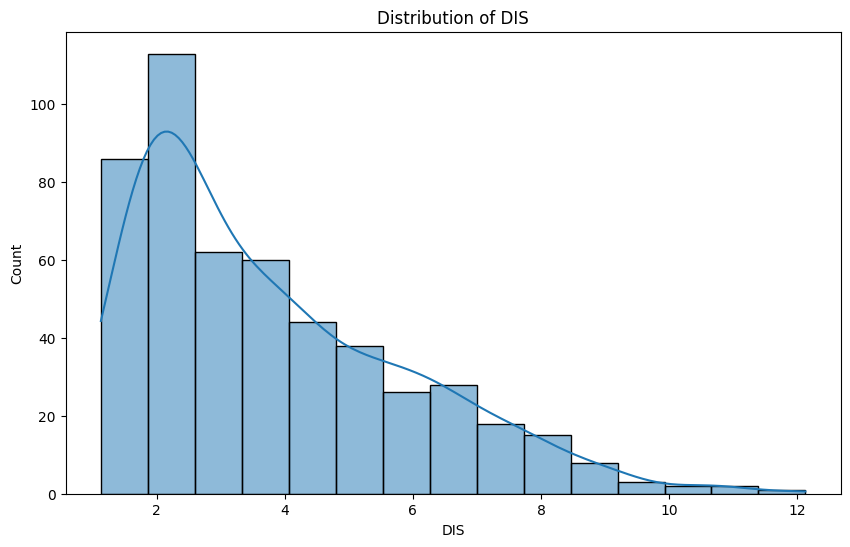

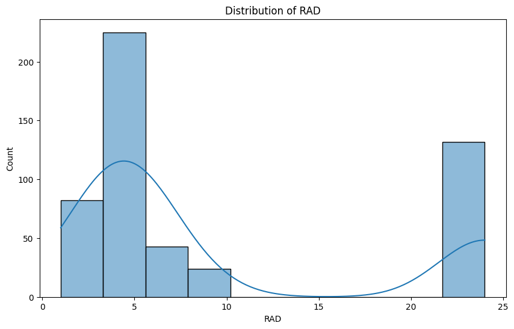

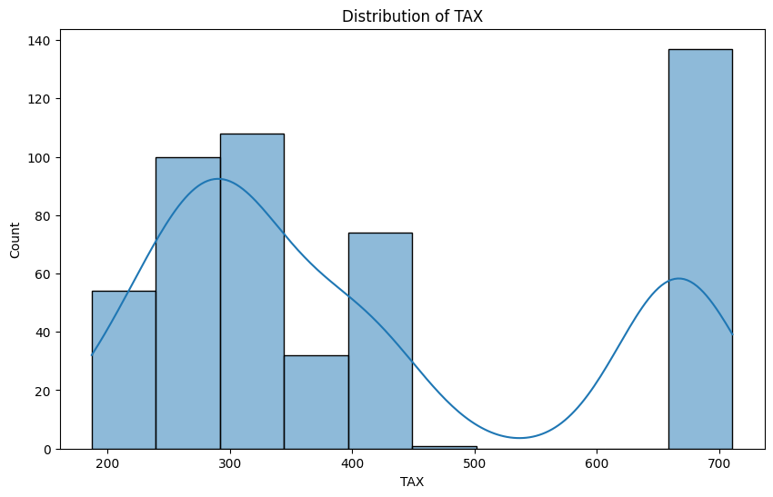

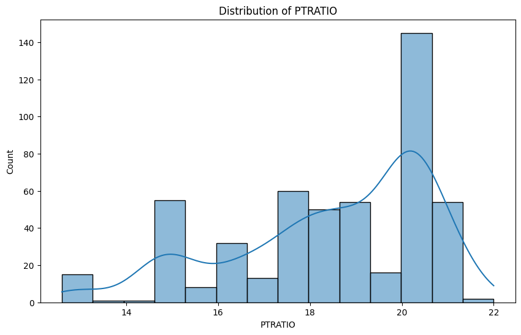

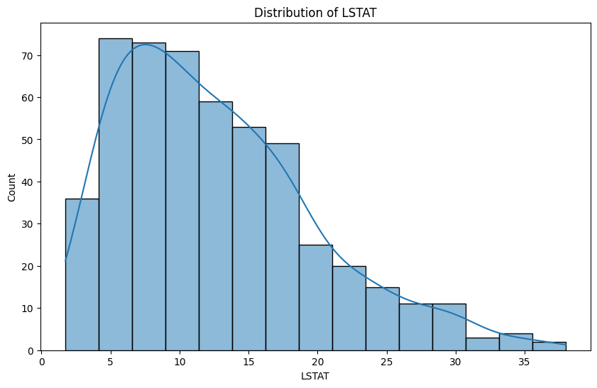

[1 more figures not shown]

```python
for column in boston.columns:
    plt.figure(figsize=(10, 6))
    sns.histplot(boston[column], kde=True)
    plt.title(f'Distribution of {column}')
    plt.show()
```

INDUS and NOX (0.76): Higher industrial activity is associated with higher NOX levels, indicating higher pollution in industrial areas.

INDUS and DIS (-0.71): Higher industrial activity is associated with shorter distances to employment centers, suggesting that industrial areas are closer to employment hubs.

INDUS and TAX (0.72): Higher industrial activity is associated with higher property tax rates.

NOX and AGE (0.73): Older houses are associated with higher NOX levels, suggesting that older areas might be more polluted.

NOX and DIS (-0.77): Higher NOX levels are associated with shorter distances to employment centers, indicating that more polluted areas are closer to employment hubs.

AGE and DIS (-0.75): Older houses are associated with shorter distances to employment centers.

RAD and TAX (0.91): Higher accessibility to radial highways is strongly associated with higher property tax rates.

LSTAT and MEDV (-0.74): Higher percentages of lower status population are associated with lower median home values.

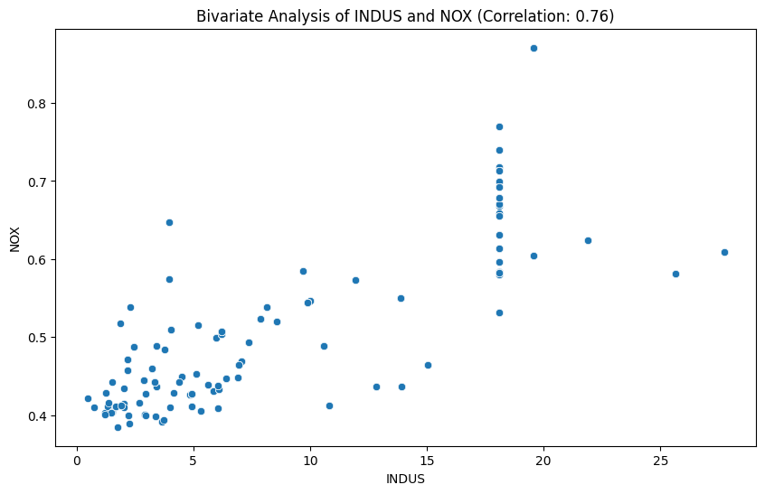

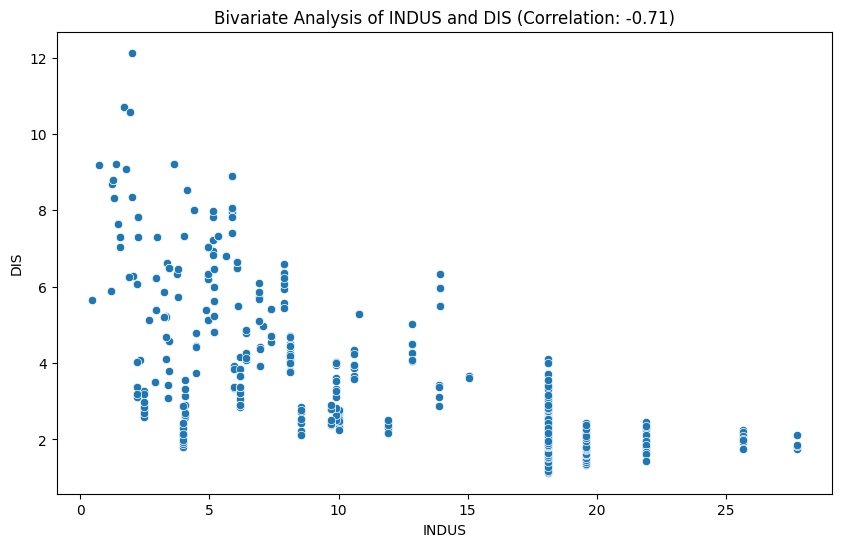

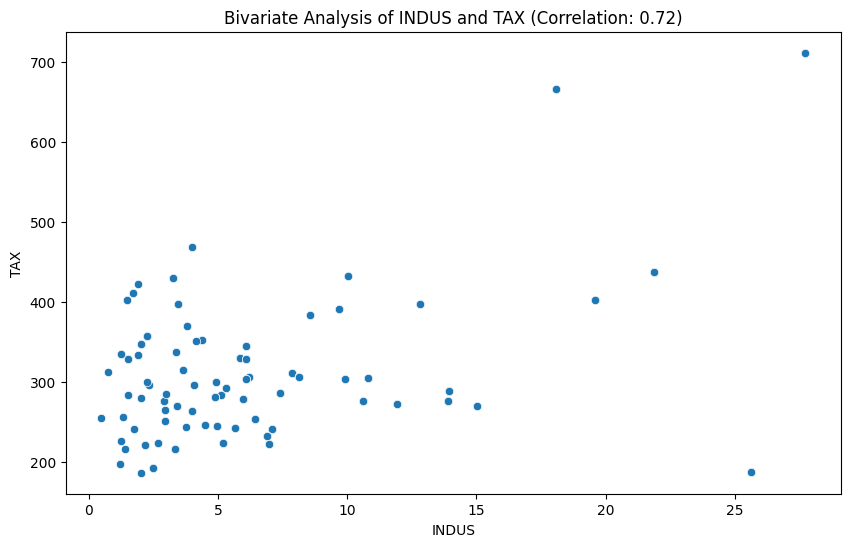

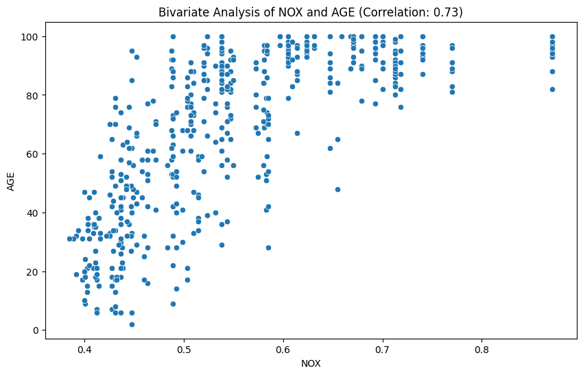

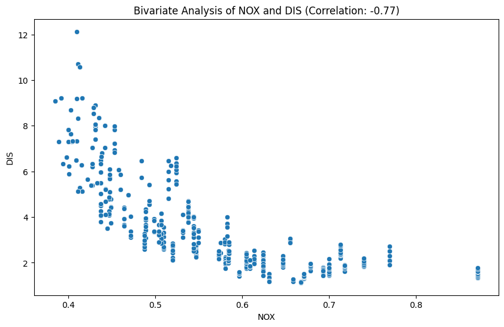

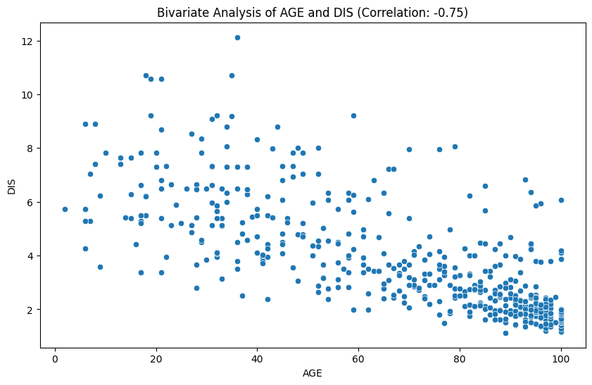

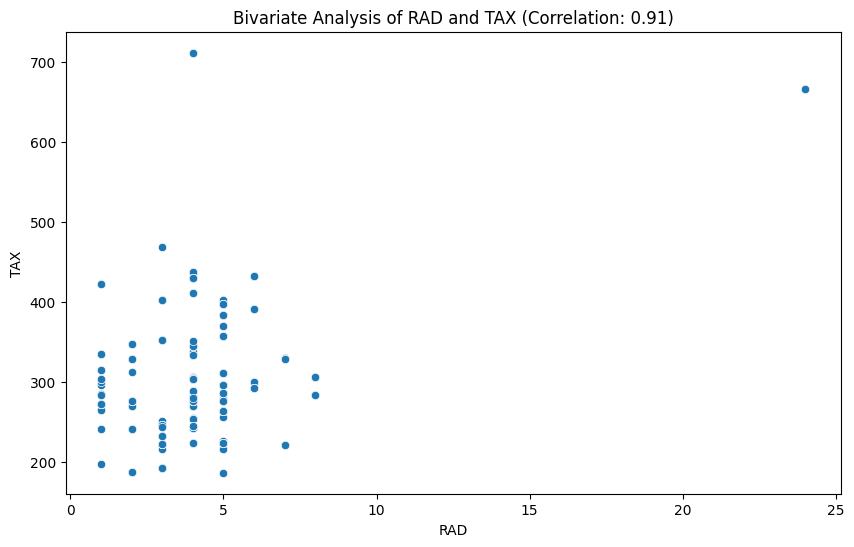

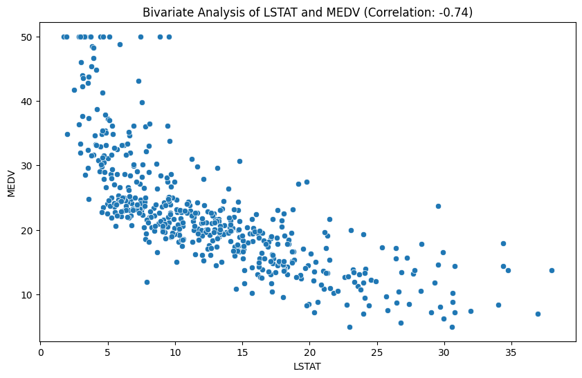

```python
correlation_matrix = boston.corr()
high_corr_var = np.where((correlation_matrix >= 0.7) | (correlation_matrix <= -0.7))
high_corr_var = [(correlation_matrix.columns[x], correlation_matrix.columns[y], correlation_matrix.iloc[x, y]) for x, y in zip(*high_corr_var) if x != y and x < y]

for var1, var2, corr_value in high_corr_var:
    plt.figure(figsize=(10, 6))
    sns.scatterplot(x=boston[var1], y=boston[var2])
    plt.title(f'Bivariate Analysis of {var1} and {var2} (Correlation: {corr_value:.2f})')
    plt.xlabel(var1)
    plt.ylabel(var2)
    plt.show()
```

The analysis shows significant correlations between several features, indicating relationships that should be considered when building predictive models. Variables like NOX, AGE, and DIS show strong relationships with industrial activity and pollution, while LSTAT and RM are crucial in predicting home values.

## Data Preprocessing

- Missing value treatment
- Log transformation of dependent variable if skewed
- Feature engineering (if needed)
- Outlier detection and treatment (if needed)
- Preparing data for modeling
- Any other preprocessing steps (if needed)

```python
# Checking for missing values
missing_values = boston.isnull().sum()
print("Missing Values:\n", missing_values)
print()

# Checking for duplicate values
duplicate_values = boston.duplicated().sum()
print(f"Number of duplicate rows: {duplicate_values}")
print()

# Checking for any anomalies or inconsistencies in the data types
print("Data Types:\n", boston.dtypes)
print()

# Checking for any negative values in features where they do not make sense (e.g., crime rate, number of rooms)
negative_values = (boston < 0).sum()
print("Negative Values in Each Column:\n", negative_values)
```

```
Missing Values:
 CRIM       0
ZN         0
INDUS      0
CHAS       0
NOX        0
RM         0
AGE        0
DIS        0
RAD        0
TAX        0
PTRATIO    0
LSTAT      0
MEDV       0
dtype: int64

Number of duplicate rows: 0

Data Types:
 CRIM       float64
ZN         float64
INDUS      float64
CHAS         int64
NOX        float64
RM           int64
AGE          int64
DIS        float64
RAD          int64
TAX          int64
PTRATIO    float64
LSTAT      float64
MEDV       float64
dtype: object

Negative Values in Each Column:
 CRIM       0
ZN         0
INDUS      0
CHAS       0
NOX        0
RM         0
AGE        0
DIS        0
RAD        0
TAX        0
PTRATIO    0
LSTAT      0
MEDV       0
dtype: int64
```

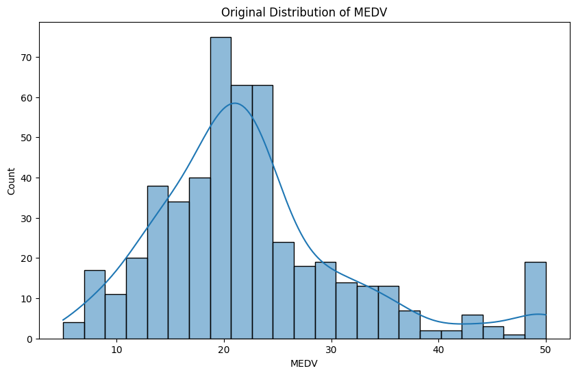

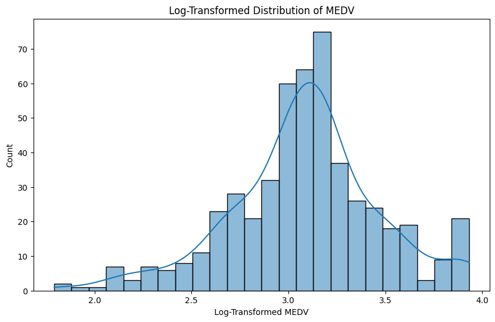

```python
# Original distribution of MEDV
plt.figure(figsize=(10, 6))
sns.histplot(boston['MEDV'], kde=True)
plt.title('Original Distribution of MEDV')
plt.xlabel('MEDV')
plt.show()

# Log transformation of MEDV
boston['MEDV_log'] = np.log1p(boston['MEDV'])

# Distribution of log-transformed MEDV
plt.figure(figsize=(10, 6))
sns.histplot(boston['MEDV_log'], kde=True)
plt.title('Log-Transformed Distribution of MEDV')
plt.xlabel('Log-Transformed MEDV')
plt.show()
```

### Checking for outliers

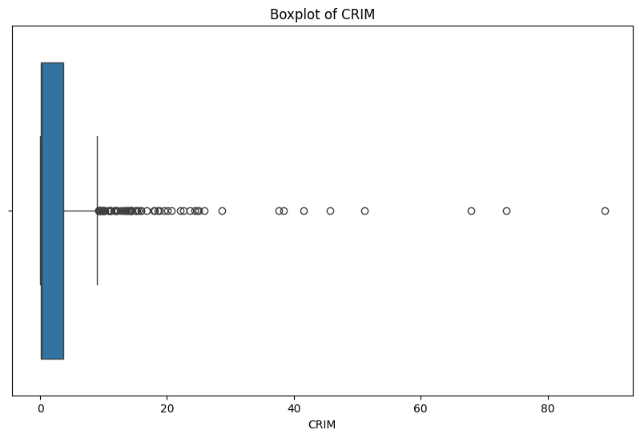

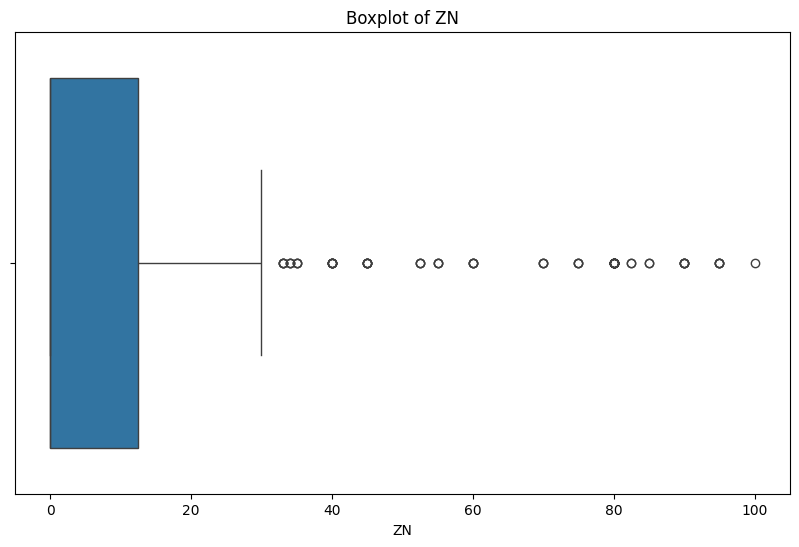

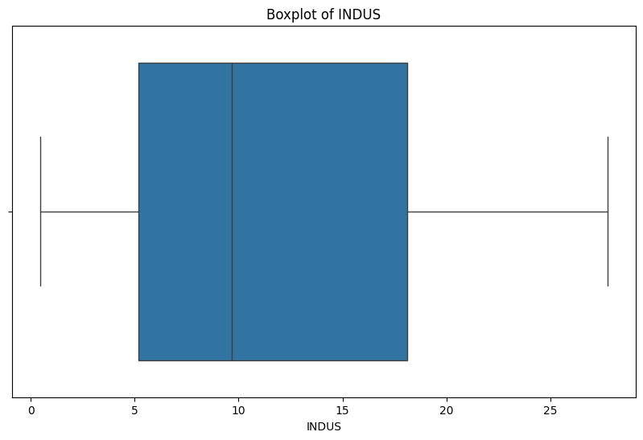

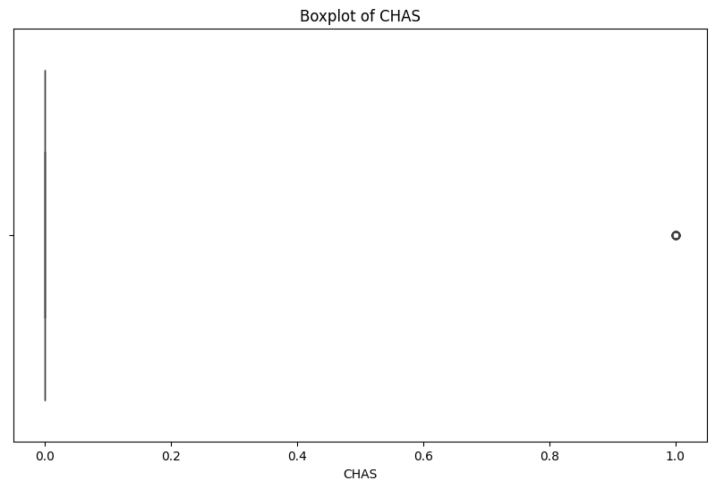

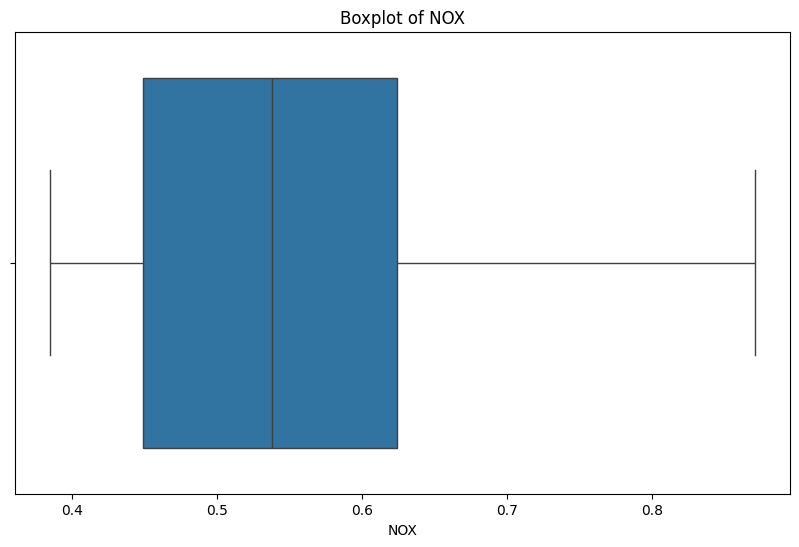

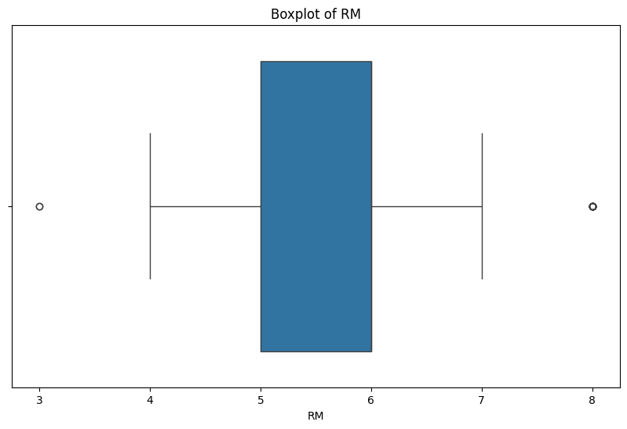

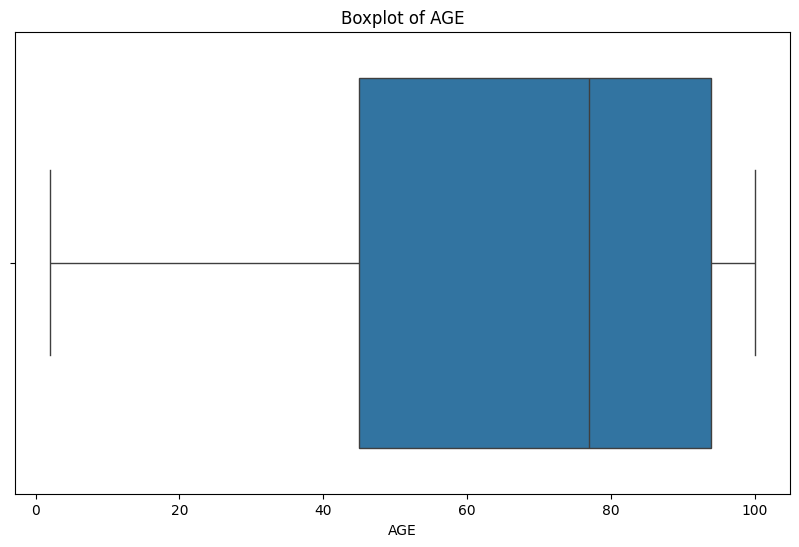

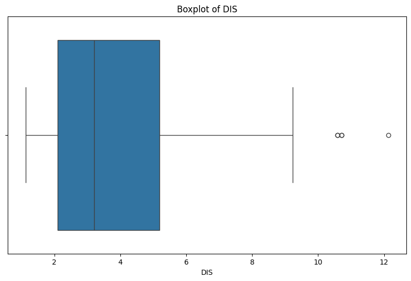

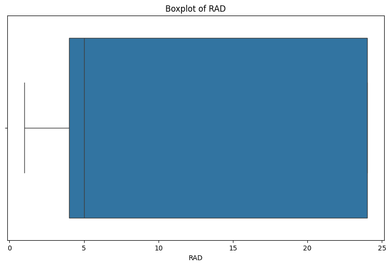

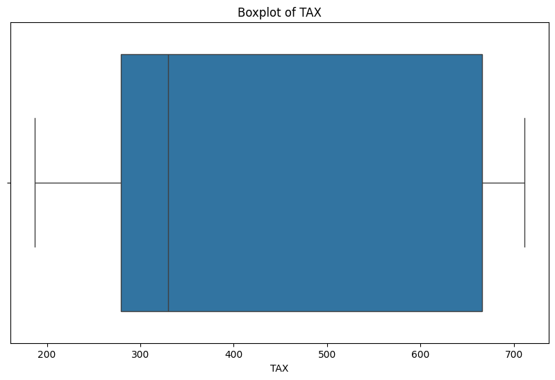

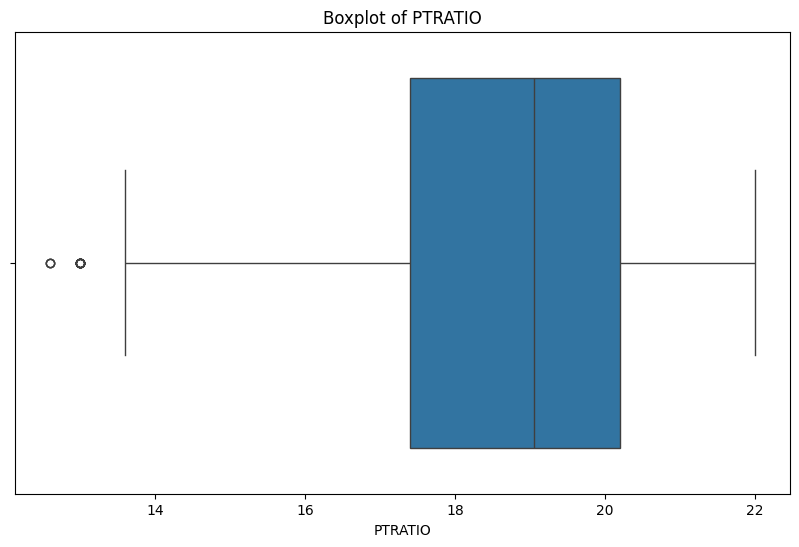

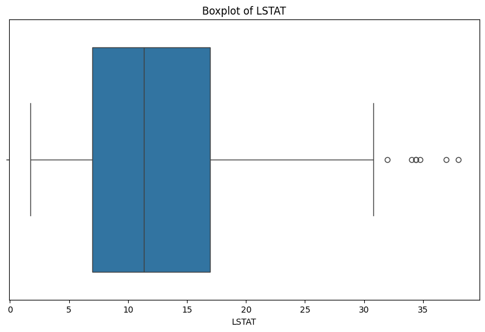

[2 more figures not shown]

```python
for column in boston.columns:
    plt.figure(figsize=(10, 6))
    sns.boxplot(x=boston[column])
    plt.title(f'Boxplot of {column}')
    plt.show()
```

```python
# Feature Engineering
boston['CRIM'] = np.log1p(boston['CRIM'])
boston['ZN'] = np.log1p(boston['ZN'])
boston['MEDV_log'] = np.log1p(boston['MEDV'])
boston['RM_squared'] = boston['RM'] ** 2
boston['LSTAT_squared'] = boston['LSTAT'] ** 2
boston.drop(columns=['MEDV'], inplace=True)
```

```python
# Prepare data for modeling (scaling)
X = boston.drop('MEDV_log', axis=1)
y = boston['MEDV_log']
scaler = StandardScaler()
X_scaled = scaler.fit_transform(X)
```

```python
boston.head()
```

|  | CRIM | ZN | INDUS | CHAS | NOX | RM | AGE | DIS | RAD | TAX | PTRATIO | LSTAT | MEDV_log | RM_squared | LSTAT_squared |
| --- | --- | --- | --- | --- | --- | --- | --- | --- | --- | --- | --- | --- | --- | --- | --- |
| 0 | 0.006300 | 2.944439 | 2.31 | 0 | 0.538 | 6 | 65 | 4.0900 | 1 | 296 | 15.3 | 4.98 | 3.218876 | 36 | 24.8004 |
| 1 | 0.026944 | 0.000000 | 7.07 | 0 | 0.469 | 6 | 78 | 4.9671 | 2 | 242 | 17.8 | 9.14 | 3.117950 | 36 | 83.5396 |
| 2 | 0.026924 | 0.000000 | 7.07 | 0 | 0.469 | 7 | 61 | 4.9671 | 2 | 242 | 17.8 | 4.03 | 3.575151 | 49 | 16.2409 |
| 3 | 0.031857 | 0.000000 | 2.18 | 0 | 0.458 | 6 | 45 | 6.0622 | 3 | 222 | 18.7 | 2.94 | 3.538057 | 36 | 8.6436 |
| 4 | 0.066770 | 0.000000 | 2.18 | 0 | 0.458 | 7 | 54 | 6.0622 | 3 | 222 | 18.7 | 5.33 | 3.616309 | 49 | 28.4089 |

## Model Building - Linear Regression

```python
X_train, X_test, y_train, y_test = train_test_split(X_scaled, y, test_size=0.2, random_state=42)

models = {
    "Linear Regression": LinearRegression(),
    "Ridge Regression": Ridge(),
    "Lasso Regression": Lasso()
}
```

## Model Performance Check

1. How does the model is performing? Check using Rsquared, RSME, MAE, MAPE
2. Is there multicollinearity? Check using VIF
3. How does the model is performing after cross validation?

```python
performance_data = []

for name, model in models.items():
    model.fit(X_train, y_train)
    y_pred = model.predict(X_test)
    performance_data.append({
        "Model": name,
        "R-squared": r2_score(y_test, y_pred),
        "RMSE": mean_squared_error(y_test, y_pred, squared=False),
        "MAE": mean_absolute_error(y_test, y_pred),
        "MAPE": mean_absolute_percentage_error(y_test, y_pred)
    })

performance_df = pd.DataFrame(performance_data).set_index('Model')
performance_df
```

| Model | R-squared | RMSE | MAE | MAPE |
| --- | --- | --- | --- | --- |
| Linear Regression | 0.797283 | 0.167679 | 0.114077 | 0.039211 |
| Ridge Regression | 0.798115 | 0.167335 | 0.112514 | 0.038674 |
| Lasso Regression | -0.018268 | 0.375808 | 0.268233 | 0.094907 |

```python
linear_models = ['Linear Regression', 'Ridge Regression', 'Lasso Regression']

for model_name in linear_models:
    if model_name in models:
        model = models[model_name]  # Retrieving the model instance
        coefficients = model.coef_  # Getting the model coefficients
        intercept = model.intercept_  # Getting the model intercept
        features = X.columns  # Getting the feature names from the DataFrame

        # Creating a DataFrame with feature names and their corresponding coefficients
        coef_df = pd.DataFrame({
            'Feature': features,
            'Coefficient': coefficients
        })
        print()

        intercept_df = pd.DataFrame({
            'Feature': ['Intercept'],
            'Coefficient': [intercept]
        })
        print()
        coef_df = pd.concat([intercept_df, coef_df], ignore_index=True)

        print(f"Coefficients and Intercept ({model_name}):\n", coef_df)
```

```
Coefficients and Intercept (Linear Regression):
           Feature  Coefficient
0       Intercept     3.084867
1            CRIM    -0.183450
2              ZN     0.007816
3           INDUS     0.032314
4            CHAS     0.025104
5             NOX    -0.057748
6              RM    -0.495782
7             AGE     0.016248
8             DIS    -0.078272
9             RAD     0.162064
10            TAX    -0.071861
11        PTRATIO    -0.071020
12          LSTAT    -0.377129
```

[output cut: 40 more lines]

```python
# Check for multicollinearity using VIF
vif_data = pd.DataFrame()
vif_data['Feature'] = X.columns
vif_data['VIF'] = [variance_inflation_factor(X_scaled, i) for i in range(X_scaled.shape[1])]
vif_data
```

|  | Feature | VIF |
| --- | --- | --- |
| 0 | CRIM | 8.420070 |
| 1 | ZN | 2.579497 |
| 2 | INDUS | 4.025708 |
| 3 | CHAS | 1.075897 |
| 4 | NOX | 4.480559 |
| 5 | RM | 94.691142 |
| 6 | AGE | 3.304498 |
| 7 | DIS | 4.123819 |
| 8 | RAD | 11.320315 |
| 9 | TAX | 8.628031 |
| 10 | PTRATIO | 1.988510 |
| 11 | LSTAT | 24.421458 |
| 12 | RM_squared | 98.072824 |
| 13 | LSTAT_squared | 19.072961 |

```python
cv_results = []

for name, model in models.items():
    cv_scores = cross_val_score(model, X_scaled, y, cv=5, scoring='r2')
    cv_results.append({
        "Model": name,
        "Mean CV R-squared": np.mean(cv_scores),
        "Std CV R-squared": np.std(cv_scores)
    })

cv_results_df = pd.DataFrame(cv_results).set_index('Model')
cv_results_df
```

| Model | Mean CV R-squared | Std CV R-squared |
| --- | --- | --- |
| Linear Regression | 0.658050 | 0.080796 |
| Ridge Regression | 0.654437 | 0.072023 |
| Lasso Regression | -0.704229 | 0.773495 |

## Checking Linear Regression Assumptions

- In order to make statistical inferences from a linear regression model, it is important to ensure that the assumptions of linear regression are satisfied.

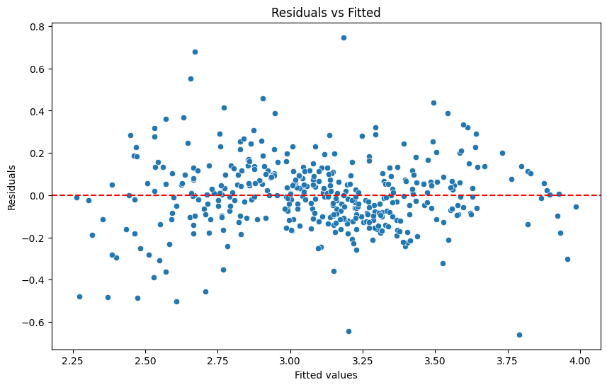

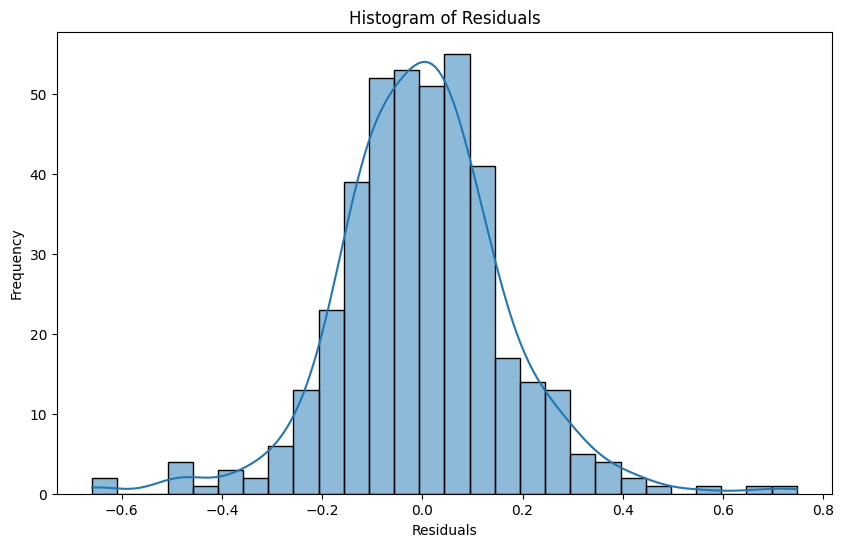

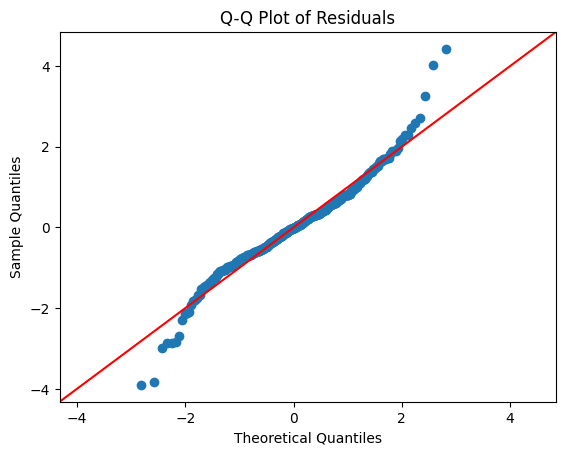

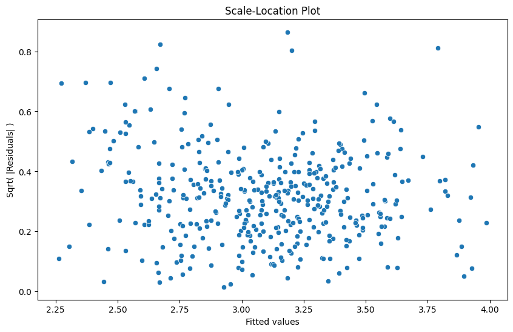

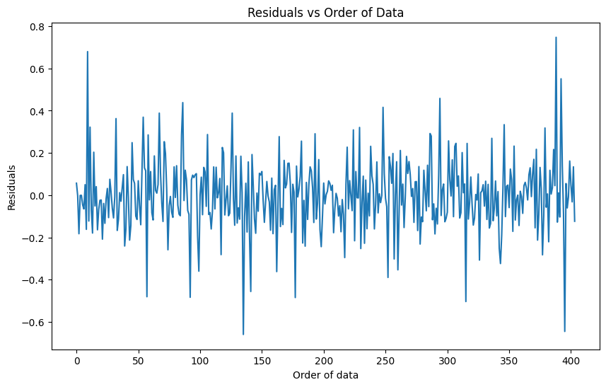

```python
# Fitting the model using statsmodels for detailed output
X_train_sm = sm.add_constant(X_train)  # Adding a constant term for the intercept
model_sm = sm.OLS(y_train, X_train_sm).fit()

# Printing the summary of the model
model_sm.summary()

# Prediction using the model
y_train_pred = model_sm.predict(X_train_sm)
residuals = y_train - y_train_pred

# Linearity
plt.figure(figsize=(10, 6))
sns.scatterplot(x=y_train_pred, y=residuals)
plt.axhline(0, color='red', linestyle='--')
plt.title('Residuals vs Fitted')
plt.xlabel('Fitted values')
plt.ylabel('Residuals')
plt.show()

# Normality of residuals
plt.figure(figsize=(10, 6))
sns.histplot(residuals, kde=True)
plt.title('Histogram of Residuals')
plt.xlabel('Residuals')
plt.ylabel('Frequency')
plt.show()

sm.qqplot(residuals, line='45', fit=True)
plt.title('Q-Q Plot of Residuals')
plt.show()

# Homoscedasticity
plt.figure(figsize=(10, 6))
sns.scatterplot(x=y_train_pred, y=np.sqrt(np.abs(residuals)))
plt.title('Scale-Location Plot')
plt.xlabel('Fitted values')
plt.ylabel('Sqrt( |Residuals| )')
plt.show()

# Independence
plt.figure(figsize=(10, 6))
sns.lineplot(x=np.arange(len(residuals)), y=residuals)
plt.title('Residuals vs Order of Data')
plt.xlabel('Order of data')
plt.ylabel('Residuals')
plt.show()
```

**Residuals vs Fitted Values Plot:**

The residuals are scattered randomly around the horizontal line (red line at zero), indicating that the linear relationship assumption holds true. There is no clear pattern in the residuals, which suggests that the model fits well and there is no major misspecification.

**Histogram of Residuals:**

The residuals follow an approximately normal distribution with a mean of zero, as indicated by the bell-shaped curve. This suggests that the normality assumption of the residuals is reasonably satisfied.

**Q-Q Plot of Residuals:**

**Scale-Location Plot:**

The spread of the residuals is roughly constant across all fitted values, indicating that the homoscedasticity assumption (constant variance of residuals) holds true. There are no clear patterns in the spread of the residuals.

**Residuals vs Order of Data Plot:**

The residuals appear to be randomly distributed with respect to the order of the data, suggesting that there is no autocorrelation. This supports the assumption of independence of residuals.

## Final Model

Since linear rgession was the best model, it will be used as the final model

```python
final_model = LinearRegression()
final_model.fit(X_scaled, y)

y_pred_final = final_model.predict(X_scaled)

final_performance = {
    "R-squared": r2_score(y, y_pred_final),
    "RMSE": mean_squared_error(y, y_pred_final, squared=False),
    "MAE": mean_absolute_error(y, y_pred_final),
    "MAPE": mean_absolute_percentage_error(y, y_pred_final)
}

print("Final Model Performance:")
print()
final_performance
```

```
Final Model Performance:
```

```
{'R-squared': 0.8105972419331666,
 'RMSE': 0.1682426058427575,
 'MAE': 0.12184199224403632,
 'MAPE': 0.041147252577001824}
```

The final model, a Linear Regression model, shows good performance with an R-squared value of approximately 0.81, indicating that around 81% of the variance in MEDV is explained by the model.

```python
final_coefficients = final_model.coef_
final_intercept = final_model.intercept_

coef_df = pd.DataFrame({
    'Feature': X.columns,
    'Coefficient': final_coefficients
})

intercept_df = pd.DataFrame({
    'Feature': ['Intercept'],
    'Coefficient': [final_intercept]
})

coef_df = pd.concat([intercept_df, coef_df], ignore_index=True)
print("Final Model Coefficients and Intercept:\n")

coef_df
```

```
Final Model Coefficients and Intercept:
```

|  | Feature | Coefficient |
| --- | --- | --- |
| 0 | Intercept | 3.085437 |
| 1 | CRIM | -0.184910 |
| 2 | ZN | 0.007489 |
| 3 | INDUS | 0.031893 |
| 4 | CHAS | 0.025522 |
| 5 | NOX | -0.060266 |
| 6 | RM | -0.466975 |
| 7 | AGE | 0.022940 |
| 8 | DIS | -0.072341 |
| 9 | RAD | 0.185532 |
| 10 | TAX | -0.088942 |
| 11 | PTRATIO | -0.072202 |
| 12 | LSTAT | -0.371382 |
| 13 | RM_squared | 0.511760 |
| 14 | LSTAT_squared | 0.156786 |

## Actionable Insights and Recommendations

```python
important_features = coef_df.sort_values(by='Coefficient', key=abs, ascending=False).head(10)
print("Top 10 Important Features:\n")
important_features
```

```
Top 10 Important Features:
```

|  | Feature | Coefficient |
| --- | --- | --- |
| 0 | Intercept | 3.085437 |
| 13 | RM_squared | 0.511760 |
| 6 | RM | -0.466975 |
| 12 | LSTAT | -0.371382 |
| 9 | RAD | 0.185532 |
| 1 | CRIM | -0.184910 |
| 14 | LSTAT_squared | 0.156786 |
| 10 | TAX | -0.088942 |
| 8 | DIS | -0.072341 |
| 11 | PTRATIO | -0.072202 |

### Recommendations:

**Reduce Crime:**

Implement crime prevention strategies such as hiring security guards to lower the crime rate (CRIM) in neighborhoods, thereby potentially increasing home values.

**Community Upliftment:**

Invest in community upliftment and social programs to reduce the proportion of lower-status population (LSTAT), as this will likely have a positive impact on home values.

**Environmental Quality:**

Focus on pollution control to reduce nitric oxide levels (NOX), especially in industrial areas, to improve residential desirability and property values. Infrastructure Development:

Invest in educational quality improvements, particularly by reducing the pupil-teacher ratio (PTRATIO), to enhance the attractiveness of neighborhoods and boost property values.

These recommendations are aimed at addressing key factors that significantly impact property values, thereby supporting strategic urban planning and development initiatives.